# Customer Churn Prediction

2024-03-08

## Regarding the Analysis: The main objective of this kernel is to improve and refine my skills in data analysis.

#### This analysis specifically focuses on the behavior of telecom customers who are more inclined to discontinue their subscription. My aim is to identify the most significant patterns in customer behavior through exploratory data analysis (EDA) and subsequently utilize predictive analytics techniques to determine the customers who are at the highest risk of churning.

## Regarding the data: (As provided in the overview/description)

#### The data includes information about customers who have terminated their subscription within the last month, which is indicated by the “Churn” column. It also encompasses the services that each customer has subscribed to, such as phone, multiple lines, internet, online security, online backup, device protection, tech support, and streaming TV and movies.

#### Additionally, the data contains customer account details, including the duration of their subscription, contract type, payment method, preference for paperless billing, monthly charges, and total charges.

#### Furthermore, demographic information about customers is included, such as their gender, age range, and whether they have partners and dependents.

```r
library(tidyverse)
library(MASS)
library(car)
library(e1071)
library(caret)
```

```r
library(cowplot)
library(caTools)
library(pROC)
library(ggcorrplot)
```

## Including Plots

```r
telco <- read.csv("WA_Fn-UseC_-Telco-Customer-Churn.csv")
```

#### 7043 observations with 21 variables.

```r
glimpse(telco)
```

```
## Rows: 7,043
## Columns: 21
## $ customerID       <chr> "7590-VHVEG", "5575-GNVDE", "3668-QPYBK", "7795-CFOCW…
## $ gender           <chr> "Female", "Male", "Male", "Male", "Female", "Female",…
## $ SeniorCitizen    <int> 0, 0, 0, 0, 0, 0, 0, 0, 0, 0, 0, 0, 0, 0, 0, 0, 0, 0,…
## $ Partner          <chr> "Yes", "No", "No", "No", "No", "No", "No", "No", "Yes…
## $ Dependents       <chr> "No", "No", "No", "No", "No", "No", "Yes", "No", "No"…
## $ tenure           <int> 1, 34, 2, 45, 2, 8, 22, 10, 28, 62, 13, 16, 58, 49, 2…
## $ PhoneService     <chr> "No", "Yes", "Yes", "No", "Yes", "Yes", "Yes", "No", …
## $ MultipleLines    <chr> "No phone service", "No", "No", "No phone service", "…
## $ InternetService  <chr> "DSL", "DSL", "DSL", "DSL", "Fiber optic", "Fiber opt…
## $ OnlineSecurity   <chr> "No", "Yes", "Yes", "Yes", "No", "No", "No", "Yes", "…
## $ OnlineBackup     <chr> "Yes", "No", "Yes", "No", "No", "No", "Yes", "No", "N…
## $ DeviceProtection <chr> "No", "Yes", "No", "Yes", "No", "Yes", "No", "No", "Y…
## $ TechSupport      <chr> "No", "No", "No", "Yes", "No", "No", "No", "No", "Yes…
## $ StreamingTV      <chr> "No", "No", "No", "No", "No", "Yes", "Yes", "No", "Ye…
## $ StreamingMovies  <chr> "No", "No", "No", "No", "No", "Yes", "No", "No", "Yes…
## $ Contract         <chr> "Month-to-month", "One year", "Month-to-month", "One …
## $ PaperlessBilling <chr> "Yes", "No", "Yes", "No", "Yes", "Yes", "Yes", "No", …
## $ PaymentMethod    <chr> "Electronic check", "Mailed check", "Mailed check", "…
## $ MonthlyCharges   <dbl> 29.85, 56.95, 53.85, 42.30, 70.70, 99.65, 89.10, 29.7…
## $ TotalCharges     <dbl> 29.85, 1889.50, 108.15, 1840.75, 151.65, 820.50, 1949…
## $ Churn            <chr> "No", "No", "Yes", "No", "Yes", "Yes", "No", "No", "Y…
```

```r
telco <- telco[complete.cases(telco),]

telco$SeniorCitizen <- as.factor(ifelse(telco$SeniorCitizen==1, 'YES', 'NO'))
```

### EXPLORATORY DATA ANALYSIS:

```r
theme1 <- theme_bw()+
theme(axis.text.x = element_text(angle = 0, hjust = 1, vjust = 0.5),legend.position="none")
theme2 <- theme_bw()+
theme(axis.text.x = element_text(angle = 90, hjust = 1, vjust = 0.5),legend.position="none")
```

```r
glimpse(telco)
```

```
## Rows: 7,032
## Columns: 21
## $ customerID       <chr> "7590-VHVEG", "5575-GNVDE", "3668-QPYBK", "7795-CFOCW…
## $ gender           <chr> "Female", "Male", "Male", "Male", "Female", "Female",…
## $ SeniorCitizen    <fct> NO, NO, NO, NO, NO, NO, NO, NO, NO, NO, NO, NO, NO, N…
## $ Partner          <chr> "Yes", "No", "No", "No", "No", "No", "No", "No", "Yes…
## $ Dependents       <chr> "No", "No", "No", "No", "No", "No", "Yes", "No", "No"…
## $ tenure           <int> 1, 34, 2, 45, 2, 8, 22, 10, 28, 62, 13, 16, 58, 49, 2…
## $ PhoneService     <chr> "No", "Yes", "Yes", "No", "Yes", "Yes", "Yes", "No", …
## $ MultipleLines    <chr> "No phone service", "No", "No", "No phone service", "…
## $ InternetService  <chr> "DSL", "DSL", "DSL", "DSL", "Fiber optic", "Fiber opt…
## $ OnlineSecurity   <chr> "No", "Yes", "Yes", "Yes", "No", "No", "No", "Yes", "…
## $ OnlineBackup     <chr> "Yes", "No", "Yes", "No", "No", "No", "Yes", "No", "N…
## $ DeviceProtection <chr> "No", "Yes", "No", "Yes", "No", "Yes", "No", "No", "Y…
## $ TechSupport      <chr> "No", "No", "No", "Yes", "No", "No", "No", "No", "Yes…
## $ StreamingTV      <chr> "No", "No", "No", "No", "No", "Yes", "Yes", "No", "Ye…
## $ StreamingMovies  <chr> "No", "No", "No", "No", "No", "Yes", "No", "No", "Yes…
## $ Contract         <chr> "Month-to-month", "One year", "Month-to-month", "One …
## $ PaperlessBilling <chr> "Yes", "No", "Yes", "No", "Yes", "Yes", "Yes", "No", …
## $ PaymentMethod    <chr> "Electronic check", "Mailed check", "Mailed check", "…
## $ MonthlyCharges   <dbl> 29.85, 56.95, 53.85, 42.30, 70.70, 99.65, 89.10, 29.7…
## $ TotalCharges     <dbl> 29.85, 1889.50, 108.15, 1840.75, 151.65, 820.50, 1949…
## $ Churn            <chr> "No", "No", "Yes", "No", "Yes", "Yes", "No", "No", "Y…
```

## VISUALIZING THE CATEGORICAL DATA FIRST WITH RESPECT TO CHURN:

- CHURN columns tells us about the number of Customers who left within the last month.
- Around 26% of customers left the platform within the last month.

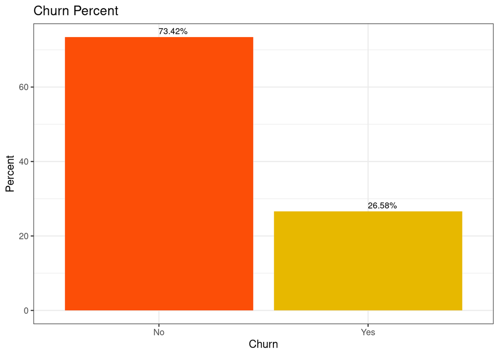

```r
options(repr.plot.width = 6, repr.plot.height = 4)
telco %>%
group_by(Churn) %>%
summarise(Count = n())%>%
mutate(percent = prop.table(Count)*100)%>%
ggplot(aes(reorder(Churn, -percent), percent), fill = Churn)+
geom_col(fill = c("#FC4E07", "#E7B800"))+
geom_text(aes(label = sprintf("%.2f%%", percent)), hjust = 0.01,vjust = -0.5, size =3)+
theme_bw()+
xlab("Churn") +
ylab("Percent")+
ggtitle("Churn Percent")
```

- Gender - The churn percent is almost equal in case of Male and Females
- The percent of churn is higher in case of senior citizens
- Customers with Partners and Dependents have lower churn rate as compared to those who don’t have * partners & Dependents.

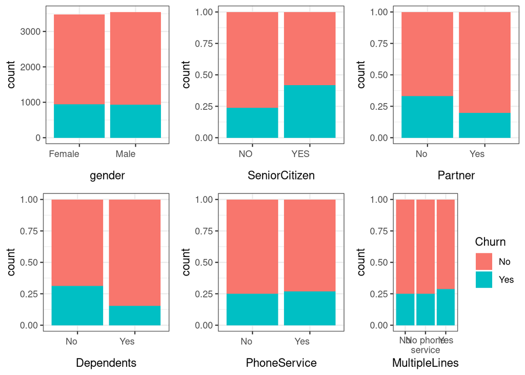

```r
options(repr.plot.width = 12, repr.plot.height = 8)
plot_grid(ggplot(telco, aes(x=gender,fill=Churn))+ geom_bar()+ theme1,
          ggplot(telco, aes(x=SeniorCitizen,fill=Churn))+ geom_bar(position = 'fill')+theme1,
          ggplot(telco, aes(x=Partner,fill=Churn))+ geom_bar(position = 'fill')+theme1,
          ggplot(telco, aes(x=Dependents,fill=Churn))+ geom_bar(position = 'fill')+theme1,
          ggplot(telco, aes(x=PhoneService,fill=Churn))+ geom_bar(position = 'fill')+theme1,
          ggplot(telco, aes(x=MultipleLines,fill=Churn))+ geom_bar(position = 'fill')+theme_bw()+
          scale_x_discrete(labels = function(x) str_wrap(x, width = 10)),
          align = "h")
```

- Churn rate is much higher in case of Fiber Optic InternetServices.
- Customers who do not have services like No OnlineSecurity , OnlineBackup and TechSupport have left the platform in the past month.

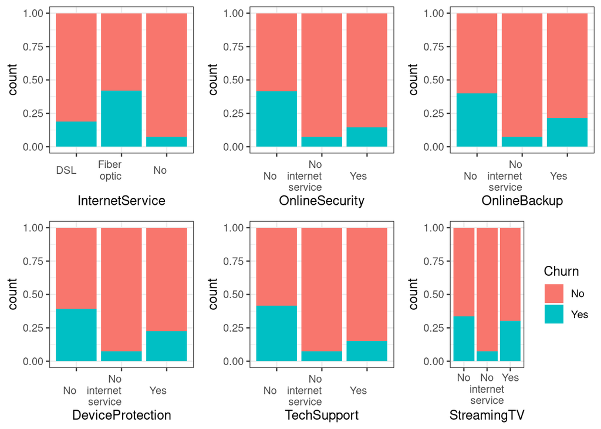

```r
options(repr.plot.width = 12, repr.plot.height = 8)
plot_grid(ggplot(telco, aes(x=InternetService,fill=Churn))+ geom_bar(position = 'fill')+ theme1+
          scale_x_discrete(labels = function(x) str_wrap(x, width = 10)),
          ggplot(telco, aes(x=OnlineSecurity,fill=Churn))+ geom_bar(position = 'fill')+theme1+
          scale_x_discrete(labels = function(x) str_wrap(x, width = 10)),
          ggplot(telco, aes(x=OnlineBackup,fill=Churn))+ geom_bar(position = 'fill')+theme1+
          scale_x_discrete(labels = function(x) str_wrap(x, width = 10)),
          ggplot(telco, aes(x=DeviceProtection,fill=Churn))+ geom_bar(position = 'fill')+theme1+
          scale_x_discrete(labels = function(x) str_wrap(x, width = 10)),
          ggplot(telco, aes(x=TechSupport,fill=Churn))+ geom_bar(position = 'fill')+theme1+
          scale_x_discrete(labels = function(x) str_wrap(x, width = 10)),
          ggplot(telco, aes(x=StreamingTV,fill=Churn))+ geom_bar(position = 'fill')+theme_bw()+
          scale_x_discrete(labels = function(x) str_wrap(x, width = 10)),
          align = "h")
```

- A larger percent of Customers with monthly subscription have left when compared to Customers with one or two year contract.
- Churn percent is higher in case of cutsomers having paperless billing option.
- Customers who have ElectronicCheck PaymentMethod tend to leave the platform more when compared to other options.

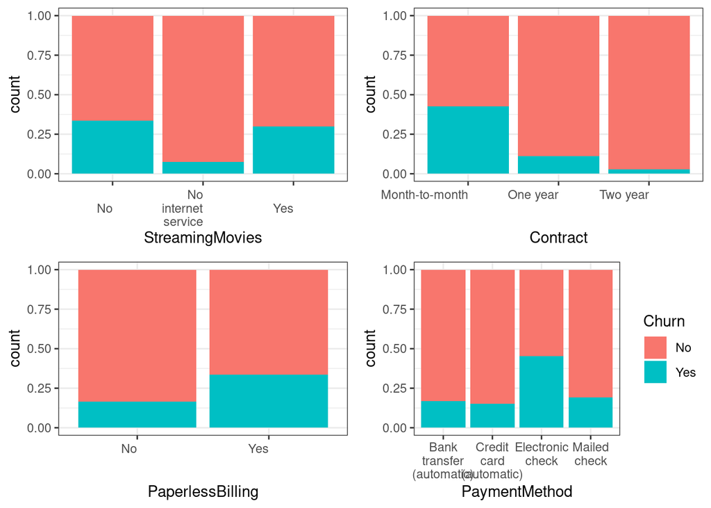

```r
plot_grid(ggplot(telco, aes(x=StreamingMovies,fill=Churn))+
          geom_bar(position = 'fill')+ theme1+
          scale_x_discrete(labels = function(x) str_wrap(x, width = 10)),
          ggplot(telco, aes(x=Contract,fill=Churn))+
          geom_bar(position = 'fill')+theme1+
          scale_x_discrete(labels = function(x) str_wrap(x, width = 10)),
          ggplot(telco, aes(x=PaperlessBilling,fill=Churn))+
          geom_bar(position = 'fill')+theme1+
          scale_x_discrete(labels = function(x) str_wrap(x, width = 10)),
          ggplot(telco, aes(x=PaymentMethod,fill=Churn))+
          geom_bar(position = 'fill')+theme_bw()+
          scale_x_discrete(labels = function(x) str_wrap(x, width = 10)),
          align = "h")
```

### Analyzing the three continuous variables w.r.t CHURN:

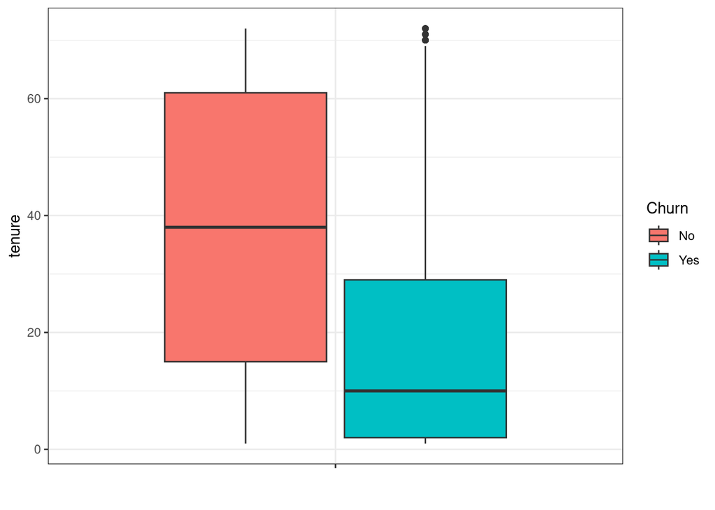

```r
options(repr.plot.width =6, repr.plot.height = 2)
ggplot(telco, aes(y= tenure, x = "", fill = Churn)) +
geom_boxplot()+
theme_bw()+
xlab(" ")
```

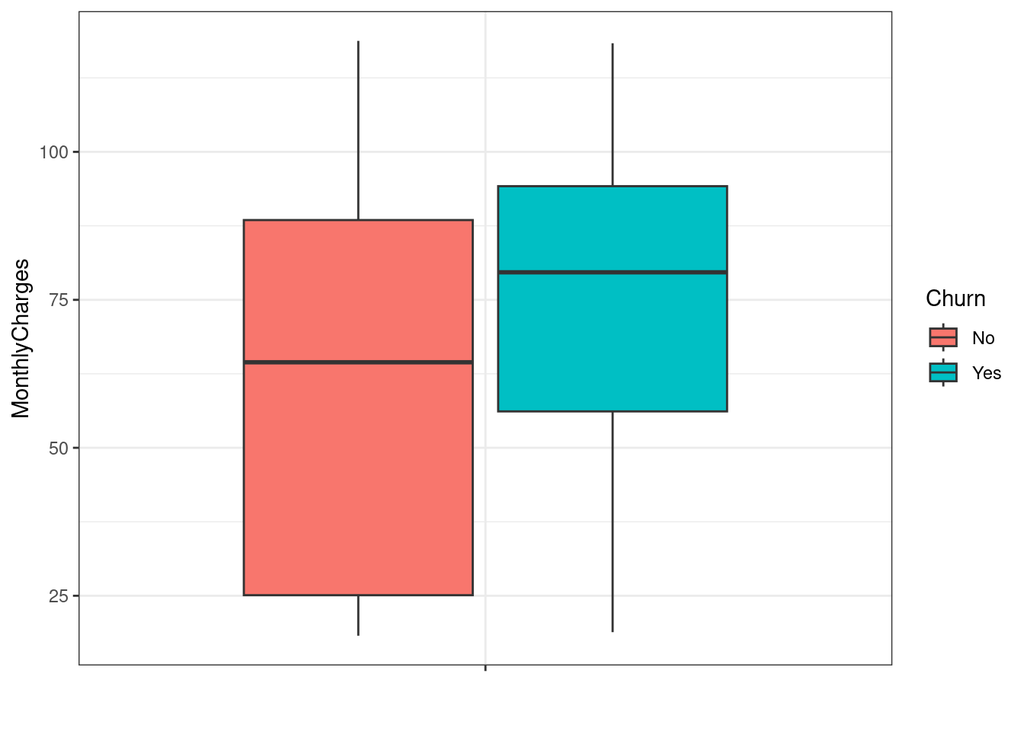

```r
ggplot(telco, aes(y= MonthlyCharges, x = "", fill = Churn)) +
geom_boxplot()+
theme_bw()+
xlab(" ")
```

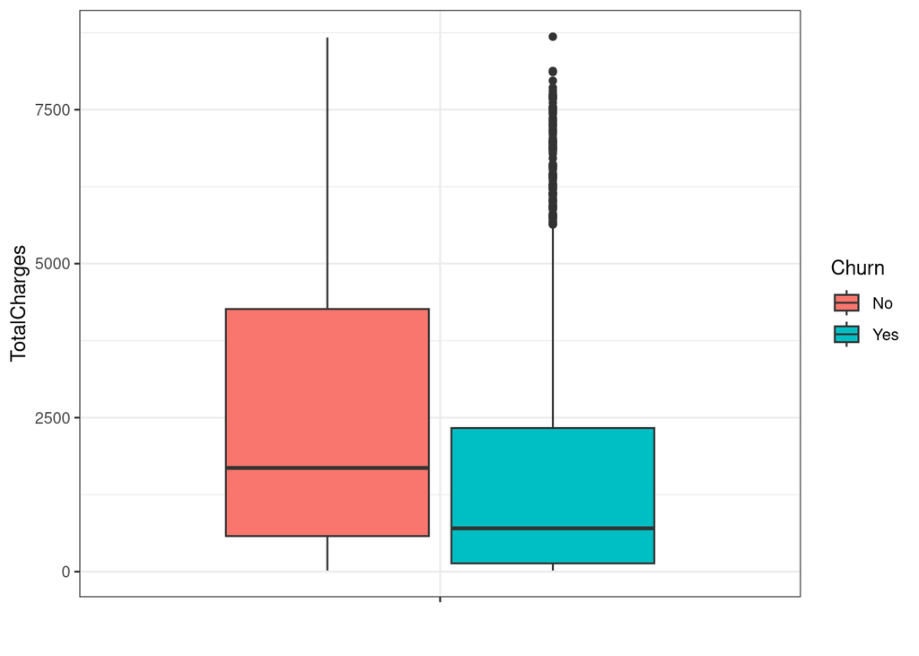

```r
ggplot(telco, aes(y= TotalCharges, x = "", fill = Churn)) +
geom_boxplot()+
theme_bw()+
xlab(" ")
```

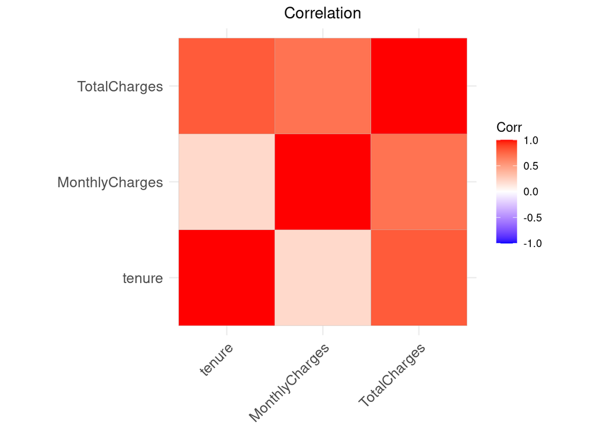

```r
options(repr.plot.width =6, repr.plot.height = 4)
telco_cor <- round(cor(telco[,c("tenure", "MonthlyCharges", "TotalCharges")]), 1)

ggcorrplot(telco_cor,  title = "Correlation")+theme(plot.title = element_text(hjust = 0.5))
```

## Data Preparation:

### Cleaning the Categorical features

### From the EDA above, we know that there are some categorical features that have ‘No’ and ‘No Internet Service’ or ‘No Phone Service’ as a category, we can make them as ‘No’ and clean these features.

```r
telco <- data.frame(lapply(telco, function(x) {
                  gsub("No internet service", "No", x)}))

telco <- data.frame(lapply(telco, function(x) {
                  gsub("No phone service", "No", x)}))
```

- Standardising Continuous features

```r
num_columns <- c("tenure", "MonthlyCharges", "TotalCharges")
telco[num_columns] <- sapply(telco[num_columns], as.numeric)

telco_int <- telco[,c("tenure", "MonthlyCharges", "TotalCharges")]
telco_int <- data.frame(scale(telco_int))
```

### Creating derived features

- I am trying to create a derived feature from tenure, where i have made different bins of tenure(which is in months) such as ‘0-1 year’, ‘2-3 years’, ‘3-4 years’ etc.

```r
#max(telco$tenure)
#min(telco$tenure)
telco <- mutate(telco, tenure_bin = tenure)

telco$tenure_bin[telco$tenure_bin >=0 & telco$tenure_bin <= 12] <- '0-1 year'
telco$tenure_bin[telco$tenure_bin > 12 & telco$tenure_bin <= 24] <- '1-2 years'
telco$tenure_bin[telco$tenure_bin > 24 & telco$tenure_bin <= 36] <- '2-3 years'
telco$tenure_bin[telco$tenure_bin > 36 & telco$tenure_bin <= 48] <- '3-4 years'
telco$tenure_bin[telco$tenure_bin > 48 & telco$tenure_bin <= 60] <- '4-5 years'
telco$tenure_bin[telco$tenure_bin > 60 & telco$tenure_bin <= 72] <- '5-6 years'

telco$tenure_bin <- as.factor(telco$tenure_bin)
```

#### After checking the distribution of data in each tenure bin, we found that maximum number of customers have a tenure of either 0-1 years and followed by 5-6 years.

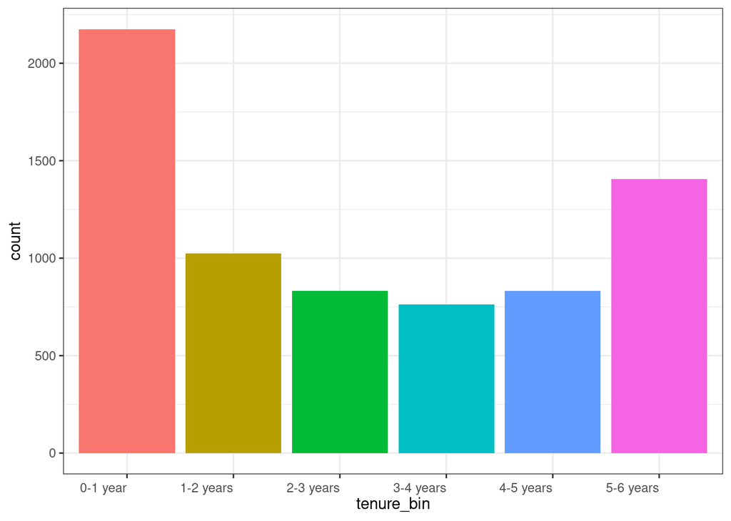

```r
options(repr.plot.width =6, repr.plot.height = 3)
ggplot(telco, aes(tenure_bin, fill = tenure_bin)) + geom_bar()+ theme1
```

#### Creating Dummy Variables

```r
telco_cat <- telco[,-c(1,6,19,20)]

#Creating Dummy Variables
dummy<- data.frame(sapply(telco_cat,function(x) data.frame(model.matrix(~x-1,data =telco_cat))[,-1]))

head(dummy)
```

|  | gender | SeniorCitizen | Partner | Dependents | PhoneService | MultipleLines | InternetService.xFiber.optic | InternetService.xNo | OnlineSecurity | OnlineBackup | DeviceProtection | TechSupport | StreamingTV | StreamingMovies | Contract.xOne.year | Contract.xTwo.year | PaperlessBilling | PaymentMethod.xCredit.card..automatic. | PaymentMethod.xElectronic.check | PaymentMethod.xMailed.check | Churn | tenure_bin.x1.2.years | tenure_bin.x2.3.years | tenure_bin.x3.4.years | tenure_bin.x4.5.years | tenure_bin.x5.6.years |
| --- | --- | --- | --- | --- | --- | --- | --- | --- | --- | --- | --- | --- | --- | --- | --- | --- | --- | --- | --- | --- | --- | --- | --- | --- | --- | --- |
| 1 | 0 | 0 | 1 | 0 | 0 | 0 | 0 | 0 | 0 | 1 | 0 | 0 | 0 | 0 | 0 | 0 | 1 | 0 | 1 | 0 | 0 | 0 | 0 | 0 | 0 | 0 |
| 2 | 1 | 0 | 0 | 0 | 1 | 0 | 0 | 0 | 1 | 0 | 1 | 0 | 0 | 0 | 1 | 0 | 0 | 0 | 0 | 1 | 0 | 0 | 1 | 0 | 0 | 0 |
| 3 | 1 | 0 | 0 | 0 | 1 | 0 | 0 | 0 | 1 | 1 | 0 | 0 | 0 | 0 | 0 | 0 | 1 | 0 | 0 | 1 | 1 | 0 | 0 | 0 | 0 | 0 |
| 4 | 1 | 0 | 0 | 0 | 0 | 0 | 0 | 0 | 1 | 0 | 1 | 1 | 0 | 0 | 1 | 0 | 0 | 0 | 0 | 0 | 0 | 0 | 0 | 1 | 0 | 0 |
| 5 | 0 | 0 | 0 | 0 | 1 | 0 | 1 | 0 | 0 | 0 | 0 | 0 | 0 | 0 | 0 | 0 | 1 | 0 | 1 | 0 | 1 | 0 | 0 | 0 | 0 | 0 |
| 6 | 0 | 0 | 0 | 0 | 1 | 1 | 1 | 0 | 0 | 0 | 1 | 0 | 1 | 1 | 0 | 0 | 1 | 0 | 1 | 0 | 1 | 0 | 0 | 0 | 0 | 0 |

#### Creating the final dataset by combining the numeric and dummy data frames.

```r
#Combining the data
telco_final <- cbind(telco_int,dummy)
head(telco_final)
```

|  | tenure | MonthlyCharges | TotalCharges | gender | SeniorCitizen | Partner | Dependents | PhoneService | MultipleLines | InternetService.xFiber.optic | InternetService.xNo | OnlineSecurity | OnlineBackup | DeviceProtection | TechSupport | StreamingTV | StreamingMovies | Contract.xOne.year | Contract.xTwo.year | PaperlessBilling | PaymentMethod.xCredit.card..automatic. | PaymentMethod.xElectronic.check | PaymentMethod.xMailed.check | Churn | tenure_bin.x1.2.years | tenure_bin.x2.3.years | tenure_bin.x3.4.years | tenure_bin.x4.5.years | tenure_bin.x5.6.years |
| --- | --- | --- | --- | --- | --- | --- | --- | --- | --- | --- | --- | --- | --- | --- | --- | --- | --- | --- | --- | --- | --- | --- | --- | --- | --- | --- | --- | --- | --- |
| 1 | -1.28015700 | -1.1616113 | -0.9941234 | 0 | 0 | 1 | 0 | 0 | 0 | 0 | 0 | 0 | 1 | 0 | 0 | 0 | 0 | 0 | 0 | 1 | 0 | 1 | 0 | 0 | 0 | 0 | 0 | 0 | 0 |
| 2 | 0.06429811 | -0.2608594 | -0.1737275 | 1 | 0 | 0 | 0 | 1 | 0 | 0 | 0 | 1 | 0 | 1 | 0 | 0 | 0 | 1 | 0 | 0 | 0 | 0 | 1 | 0 | 0 | 1 | 0 | 0 | 0 |
| 3 | -1.23941594 | -0.3638974 | -0.9595809 | 1 | 0 | 0 | 0 | 1 | 0 | 0 | 0 | 1 | 1 | 0 | 0 | 0 | 0 | 0 | 0 | 1 | 0 | 0 | 1 | 1 | 0 | 0 | 0 | 0 | 0 |
| 4 | 0.51244982 | -0.7477972 | -0.1952338 | 1 | 0 | 0 | 0 | 0 | 0 | 0 | 0 | 1 | 0 | 1 | 1 | 0 | 0 | 1 | 0 | 0 | 0 | 0 | 0 | 0 | 0 | 0 | 1 | 0 | 0 |
| 5 | -1.23941594 | 0.1961642 | -0.9403906 | 0 | 0 | 0 | 0 | 1 | 0 | 1 | 0 | 0 | 0 | 0 | 0 | 0 | 0 | 0 | 0 | 1 | 0 | 1 | 0 | 1 | 0 | 0 | 0 | 0 | 0 |
| 6 | -0.99496955 | 1.1584066 | -0.6453233 | 0 | 0 | 0 | 0 | 1 | 1 | 1 | 0 | 0 | 0 | 1 | 0 | 1 | 1 | 0 | 0 | 1 | 0 | 1 | 0 | 1 | 0 | 0 | 0 | 0 | 0 |

#### Splitting the data into train and validation data.

```r
#Splitting the data
set.seed(123)
indices = sample.split(telco_final$Churn, SplitRatio = 0.7)
train = telco_final[indices,]
validation = telco_final[!(indices),]
```

### Model Building with Logistic Regression

```r
#Build the first model using all variables
model_1 = glm(Churn ~ ., data = train, family = "binomial")
summary(model_1)
```

```
##
## Call:
## glm(formula = Churn ~ ., family = "binomial", data = train)
##
## Deviance Residuals:
##     Min       1Q   Median       3Q      Max
## -2.0959  -0.6765  -0.2674   0.6331   3.3919
##
## Coefficients:
##                                         Estimate Std. Error z value Pr(>|z|)
## (Intercept)                            -4.711690   1.580952  -2.980 0.002880
## tenure                                 -2.419264   0.319733  -7.567 3.83e-14
## MonthlyCharges                         -1.523039   1.152472  -1.322 0.186321
## TotalCharges                            0.236922   0.200225   1.183 0.236699
## gender                                 -0.004319   0.078799  -0.055 0.956292
## SeniorCitizen                           0.342668   0.102039   3.358 0.000784
## Partner                                 0.049639   0.095330   0.521 0.602570
## Dependents                             -0.148501   0.110427  -1.345 0.178693
## PhoneService                            0.597310   0.785026   0.761 0.446729
## MultipleLines                           0.529622   0.214832   2.465 0.013691
## InternetService.xFiber.optic            2.048017   0.960709   2.132 0.033025
## InternetService.xNo                    -2.254724   0.975826  -2.311 0.020856
## OnlineSecurity                         -0.177982   0.215524  -0.826 0.408913
## OnlineBackup                            0.126834   0.211103   0.601 0.547964
## DeviceProtection                        0.255562   0.213872   1.195 0.232114
## TechSupport                            -0.026070   0.215506  -0.121 0.903713
## StreamingTV                             0.756980   0.393508   1.924 0.054396
## StreamingMovies                         0.710913   0.394744   1.801 0.071711
## Contract.xOne.year                     -0.693044   0.130362  -5.316 1.06e-07
## Contract.xTwo.year                     -1.657976   0.233538  -7.099 1.25e-12
## PaperlessBilling                        0.384841   0.090753   4.241 2.23e-05
## PaymentMethod.xCredit.card..automatic. -0.050640   0.137167  -0.369 0.711991
## PaymentMethod.xElectronic.check         0.249223   0.113791   2.190 0.028512
## PaymentMethod.xMailed.check            -0.076660   0.138636  -0.553 0.580291
## tenure_bin.x1.2.years                   0.147347   0.191048   0.771 0.440556
## tenure_bin.x2.3.years                   0.964780   0.314795   3.065 0.002178
## tenure_bin.x3.4.years                   1.955341   0.447108   4.373 1.22e-05
## tenure_bin.x4.5.years                   2.801222   0.582303   4.811 1.50e-06
## tenure_bin.x5.6.years                   3.598926   0.728585   4.940 7.83e-07
##
```

[output cut: 24 more lines]

```
## tenure_bin.x1.2.years
## tenure_bin.x2.3.years                  **
## tenure_bin.x3.4.years                  ***
## tenure_bin.x4.5.years                  ***
## tenure_bin.x5.6.years                  ***
## ---
## Signif. codes:  0 '***' 0.001 '**' 0.01 '*' 0.05 '.' 0.1 ' ' 1
##
## (Dispersion parameter for binomial family taken to be 1)
##
##     Null deviance: 5699.5  on 4921  degrees of freedom
## Residual deviance: 3983.3  on 4893  degrees of freedom
## AIC: 4041.3
##
## Number of Fisher Scoring iterations: 6
```

#### The Variance Inflation Factor (VIF) is a tool utilized to assess the level of multicollinearity among predictor variables within a model. A predictor with a VIF of 2 or lower is typically deemed acceptable, indicating minimal correlation with other predictors. Conversely, a higher VIF suggests a stronger correlation with other predictors. It is important to note that predictors with elevated VIF values may exhibit high p-values, indicating significance. Therefore, it is crucial to evaluate the significance of predictor variables before considering their removal from the model.

```r
model_2<- stepAIC(model_1, direction="both")
```

```
## Start:  AIC=4041.29
## Churn ~ tenure + MonthlyCharges + TotalCharges + gender + SeniorCitizen +
##     Partner + Dependents + PhoneService + MultipleLines + InternetService.xFiber.optic +
##     InternetService.xNo + OnlineSecurity + OnlineBackup + DeviceProtection +
##     TechSupport + StreamingTV + StreamingMovies + Contract.xOne.year +
##     Contract.xTwo.year + PaperlessBilling + PaymentMethod.xCredit.card..automatic. +
##     PaymentMethod.xElectronic.check + PaymentMethod.xMailed.check +
##     tenure_bin.x1.2.years + tenure_bin.x2.3.years + tenure_bin.x3.4.years +
##     tenure_bin.x4.5.years + tenure_bin.x5.6.years
##
##                                          Df Deviance    AIC
## - gender                                  1   3983.3 4039.3
## - TechSupport                             1   3983.3 4039.3
## - PaymentMethod.xCredit.card..automatic.  1   3983.4 4039.4
## - Partner                                 1   3983.6 4039.6
## - PaymentMethod.xMailed.check             1   3983.6 4039.6
## - OnlineBackup                            1   3983.7 4039.7
## - PhoneService                            1   3983.9 4039.9
## - tenure_bin.x1.2.years                   1   3983.9 4039.9
## - OnlineSecurity                          1   3984.0 4040.0
## - DeviceProtection                        1   3984.7 4040.7
## - TotalCharges                            1   3984.7 4040.7
## - MonthlyCharges                          1   3985.0 4041.0
## - Dependents                              1   3985.1 4041.1
## <none>                                        3983.3 4041.3
## - StreamingMovies                         1   3986.5 4042.5
## - StreamingTV                             1   3987.0 4043.0
## - InternetService.xFiber.optic            1   3987.8 4043.8
## - PaymentMethod.xElectronic.check         1   3988.1 4044.1
## - InternetService.xNo                     1   3988.6 4044.6
## - MultipleLines                           1   3989.4 4045.4
## - tenure_bin.x2.3.years                   1   3992.7 4048.7
## - SeniorCitizen                           1   3994.5 4050.5
## - PaperlessBilling                        1   4001.4 4057.4
## - tenure_bin.x3.4.years                   1   4002.5 4058.5
## - tenure_bin.x4.5.years                   1   4006.6 4062.6
## - tenure_bin.x5.6.years                   1   4007.9 4063.9
## - Contract.xOne.year                      1   4012.9 4068.9
## - tenure                                  1   4042.6 4098.6
## - Contract.xTwo.year                      1   4046.3 4102.3
```

[output cut: 459 more lines]

```
## - PaymentMethod.xElectronic.check         1   4000.9 4036.9
## - MultipleLines                           1   4002.2 4038.2
## - StreamingMovies                         1   4002.8 4038.8
## - SeniorCitizen                           1   4002.9 4038.9
## - StreamingTV                             1   4004.6 4040.6
## - tenure_bin.x2.3.years                   1   4005.8 4041.8
## - PaperlessBilling                        1   4007.6 4043.6
## - Contract.xOne.year                      1   4019.1 4055.1
## - InternetService.xFiber.optic            1   4021.1 4057.1
## - tenure_bin.x3.4.years                   1   4031.5 4067.5
## - InternetService.xNo                     1   4038.0 4074.0
## - tenure_bin.x4.5.years                   1   4044.7 4080.7
## - tenure_bin.x5.6.years                   1   4050.1 4086.1
## - Contract.xTwo.year                      1   4055.8 4091.8
## - tenure                                  1   4137.1 4173.1
```

```r
summary(model_2)
```

```
##
## Call:
## glm(formula = Churn ~ tenure + MonthlyCharges + SeniorCitizen +
##     MultipleLines + InternetService.xFiber.optic + InternetService.xNo +
##     OnlineSecurity + StreamingTV + StreamingMovies + Contract.xOne.year +
##     Contract.xTwo.year + PaperlessBilling + PaymentMethod.xElectronic.check +
##     tenure_bin.x2.3.years + tenure_bin.x3.4.years + tenure_bin.x4.5.years +
##     tenure_bin.x5.6.years + TechSupport, family = "binomial",
##     data = train)
##
## Deviance Residuals:
##     Min       1Q   Median       3Q      Max
## -2.1461  -0.6661  -0.2733   0.6249   3.3018
##
## Coefficients:
##                                 Estimate Std. Error z value Pr(>|z|)
## (Intercept)                     -3.37123    0.27189 -12.399  < 2e-16 ***
## tenure                          -2.07853    0.17751 -11.709  < 2e-16 ***
## MonthlyCharges                  -0.52335    0.19800  -2.643 0.008213 **
## SeniorCitizen                    0.37111    0.10031   3.700 0.000216 ***
## MultipleLines                    0.38516    0.10755   3.581 0.000342 ***
## InternetService.xFiber.optic     1.28144    0.22881   5.601 2.14e-08 ***
## InternetService.xNo             -1.45816    0.20985  -6.949 3.69e-12 ***
## OnlineSecurity                  -0.33178    0.10796  -3.073 0.002118 **
## StreamingTV                      0.46276    0.11865   3.900 9.61e-05 ***
## StreamingMovies                  0.42482    0.11585   3.667 0.000246 ***
## Contract.xOne.year              -0.69055    0.12950  -5.333 9.68e-08 ***
## Contract.xTwo.year              -1.68164    0.23166  -7.259 3.89e-13 ***
## PaperlessBilling                 0.38535    0.09046   4.260 2.05e-05 ***
## PaymentMethod.xElectronic.check  0.28932    0.08445   3.426 0.000613 ***
## tenure_bin.x2.3.years            0.78164    0.19291   4.052 5.08e-05 ***
## tenure_bin.x3.4.years            1.72393    0.26800   6.432 1.26e-10 ***
## tenure_bin.x4.5.years            2.52442    0.34433   7.331 2.28e-13 ***
## tenure_bin.x5.6.years            3.30141    0.43049   7.669 1.73e-14 ***
## TechSupport                     -0.17022    0.10928  -1.558 0.119308
## ---
## Signif. codes:  0 '***' 0.001 '**' 0.01 '*' 0.05 '.' 0.1 ' ' 1
##
## (Dispersion parameter for binomial family taken to be 1)
##
##     Null deviance: 5699.5  on 4921  degrees of freedom
## Residual deviance: 3989.3  on 4903  degrees of freedom
## AIC: 4027.3
##
## Number of Fisher Scoring iterations: 6
```

```r
vif(model_2)
```

```
##                          tenure                  MonthlyCharges
##                       15.076710                       20.162188
##                   SeniorCitizen                   MultipleLines
##                        1.100707                        1.838876
##    InternetService.xFiber.optic             InternetService.xNo
##                        8.225529                        2.489968
##                  OnlineSecurity                     StreamingTV
##                        1.246308                        2.206225
##                 StreamingMovies              Contract.xOne.year
##                        2.122071                        1.386381
##              Contract.xTwo.year                PaperlessBilling
##                        1.371229                        1.125064
## PaymentMethod.xElectronic.check           tenure_bin.x2.3.years
##                        1.149683                        2.656673
##           tenure_bin.x3.4.years           tenure_bin.x4.5.years
##                        4.106103                        6.527227
##           tenure_bin.x5.6.years                     TechSupport
##                        8.568998                        1.332821
```